```r
library(tidyverse)
library(optimx)
library(numDeriv)
```

# Logistic Regression을 이용한 기업 부도 예측 (Bankruptcy Prediction)

## Data

source: Predicting Corporate Bankruptcy (Darden Business Publishing)

y: target variable

- 1 : solvent (정상)
- 0 : bankrupt (부도)

x : p=24, 재무변수 (financial ratios)

- R1 CASH/CURDEBT
- R2 CASH/SALES
- R3 CASH/ASSETS
- R4 CASH/DEBTS
- R5 CFF0/SALES
- R6 CFFO/ASSETS
- R7 CFFO/DEBTS
- R8 COGS/INV
- R9 CURASS/CURDEBT
- R10 CURASS/SALES
- R11 CURRASS/ASSETS
- R12 CURDEBT/DEBTS
- R13 INC/SALES
- R14 INC/ASSETS
- R15 INC/DEBTS
- R16 UBCDEP/SALES
- R17 INCDEP/ASSETS
- R18 INCDEP/DEBTS
- R19 SALES/REC
- R20 SALES/ASSETS
- R21 ASSETS/DEBTS
- R22 WCFO/SALES
- R23 WCFO/ASSETS
- R24 WCFO/DEBTS

# Part1. Logistic Regression

```r
bankruptcy <- read.csv("hanskins.csv", header=T)
bankruptcy <- bankruptcy[,-c(1,3)]
```

## (a) 변수선택 (Backward Elimination) 통해 최적예측모형 찾기 (AIC)

| p | AIC |
| --- | --- |
| 24 | 94.65646 |
| 23 | 92.65739 |
| 22 | 90.66070 |
| 21 | 88.67276 |
| 20 | 86.75917 |
| 19 | 84.79626 |
| 18 | 82.96319 |
| 17 | 80.98727 |
| 16 | 79.79752 |
| 15 | 78.40296 |
| 14 | 77.68357 |
| 13 | 77.52958 |
| 12 | 77.61540 |
| 11 | 77.39694 |
| 10 | 77.95218 |
| 9 | 76.24620 |
| 8 | 75.33955 |
| 7 | 73.48816 |
| 6 | 72.67480 |
| 5 | 72.11459 |
| 4 | 72.20470 |
| 3 | 84.45346 |
| 2 | 83.40494 |
| 1 | 85.08714 |

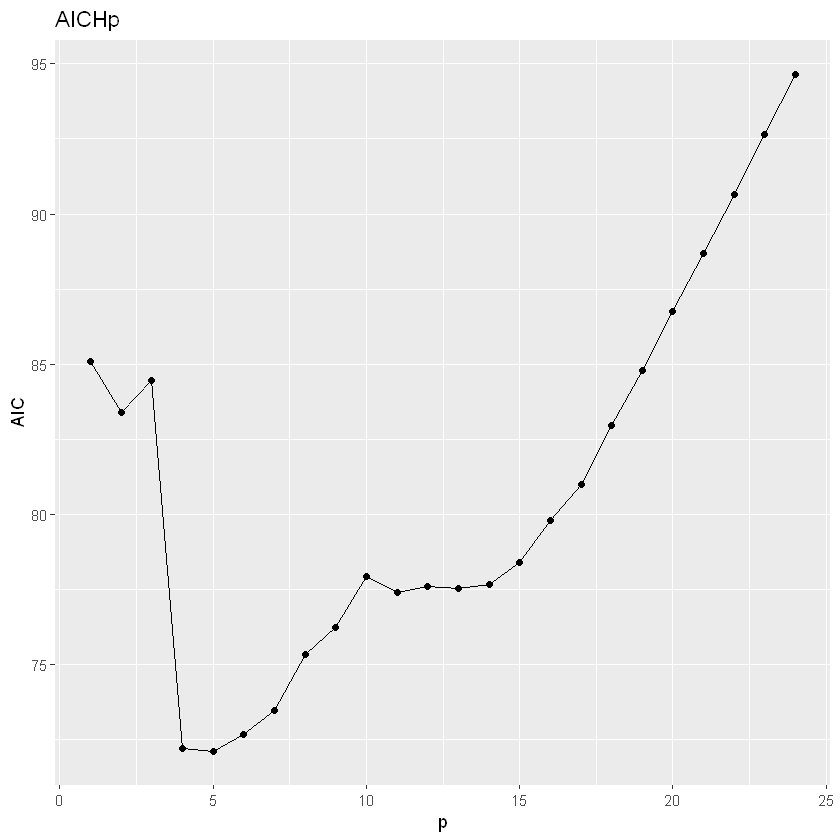

```r
AICHp <- data.frame(p=24:1, AIC=0)
variable <- list()

for (i in 1:24) {
  variable[[i]] <- colnames(bankruptcy)
  H <- glm(Y~. , data=bankruptcy, family=binomial(link = logit))
  AICHp[i,2] <- H$aic
  k <- which.max(abs(summary(H)$coef[-1,4]))
  bankruptcy <- bankruptcy[, -(k[[1]]+1)]
  # summary(H)$coef : Estimate, Std.Error, Z value, Pr(>|z|)
  # summary(H)$coef[-1,4] : intercept 제외한 나머지 중
  # bankruptcy[,-[[1]]+1] : 제일 큰 값 뺀다
}

AICHp
ggplot(AICHp,aes(p,AIC))+geom_point()+geom_line()+ggtitle("AICHp")
```

설명변수가 5개일 때 (p=5), AIC 값이 72.115로 제일 작게 나왔다.

## (b) 최적예측모형 Hp*

```r
variable[[which.min(AICHp$AIC)]]
```

1. 'Y'

2. 'R5'

3. 'R6'

4. 'R16'

5. 'R18'

6. 'R22'

```r
bankruptcy <- read.csv("hanskins.csv", header=T)
bankruptcy <- bankruptcy[,-c(1,3)]

H0 <- glm(Y ~ R5+R6+R16+R18+R22, data=bankruptcy, family=binomial(link=logit))
summary(H0)
```

```
Call:
glm(formula = Y ~ R5 + R6 + R16 + R18 + R22, family = binomial(link = logit),
    data = bankruptcy)

Deviance Residuals:
    Min       1Q   Median       3Q      Max
-1.7189  -0.4923   0.0000   0.2657   2.2575

Coefficients:
            Estimate Std. Error z value Pr(>|z|)
(Intercept)  -2.1831     0.5561  -3.926 8.64e-05 ***
R5           26.6133     8.3544   3.186 0.001445 **
R6          -29.5910     8.1330  -3.638 0.000274 ***
R16         -41.2054    14.7451  -2.795 0.005198 **
R18          31.2559     6.9454   4.500 6.79e-06 ***
R22          16.7776    12.1240   1.384 0.166409
---
Signif. codes:  0 '***' 0.001 '**' 0.01 '*' 0.05 '.' 0.1 ' ' 1

(Dispersion parameter for binomial family taken to be 1)

    Null deviance: 138.629  on 99  degrees of freedom
Residual deviance:  60.115  on 94  degrees of freedom
AIC: 72.115

Number of Fisher Scoring iterations: 8
```

최적예측모형 : Y=-2.1831 + 26.6133 *R5 + (-29.591)* R6 + (-41.2054) *R16 + 31.2559* R18 + 16.7776 * R22

## (c) H0 vs H1 : Likelihood Ratio Test

```r
library(lmtest)
```

```r
H1 <- glm(Y ~ ., data=bankruptcy, family=binomial(link=logit))
lrtest(H0, H1)
```

| #Df | LogLik | Df | Chisq | Pr(>Chisq) |
| --- | --- | --- | --- | --- |
| 6 | -30.05729 | NA | NA | NA |
| 25 | -22.32823 | 19 | 15.45812 | 0.6930695 |

p-value가 0.6931로 귀무가설을 기각하지 못한다. 따라서 H0 모델이 적절한 모형이라고 할 수 있다.

## (d) Hp* 모형의 산점도 matrix, box-plot, kernel density plot

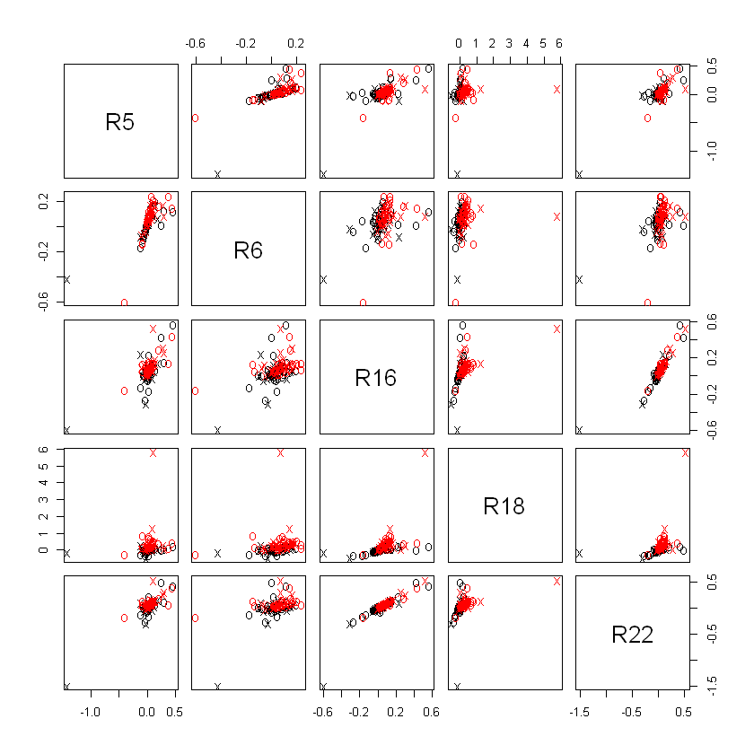

```r
bankruptcyH0 <- bankruptcy[,c("Y","R5","R6","R16","R18","R22")]
pairs(bankruptcyH0[,-c(1)],pch=c("o","x"),col=bankruptcyH0$Y+1,cex=1.3)
```

재무변수들의 산점도 matrix 를 볼 때, 부도기업(x)과 정상기업(o) 사이에 명확한 경계가 있다고 보여지지 않는다.

```r
H0.coef <- H0$coefficients
H0.coef.m <- cbind(rep(1,nrow(bankruptcy)),bankruptcy[,c("R5","R6","R16","R18","R22")])
betaX<-as.matrix(H0.coef.m)%*%as.matrix(H0.coef)
prob<-1/(1+exp(-betaX))
bankruptcy.logistic<-data.frame(Y=bankruptcy["Y"],logit=log(prob/(1-prob)))
```

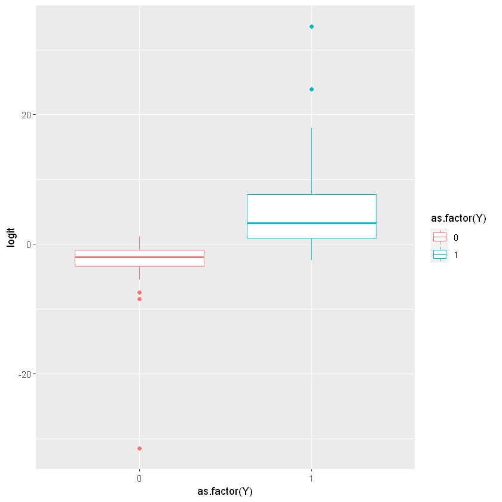

```r
ggplot(bankruptcy.logistic,aes(x=as.factor(Y),y=logit,colour=as.factor(Y)))+geom_boxplot()
```

부도기업의 예측 점수가 정상기업의 예측 점수보다 전체적으로 낮다.

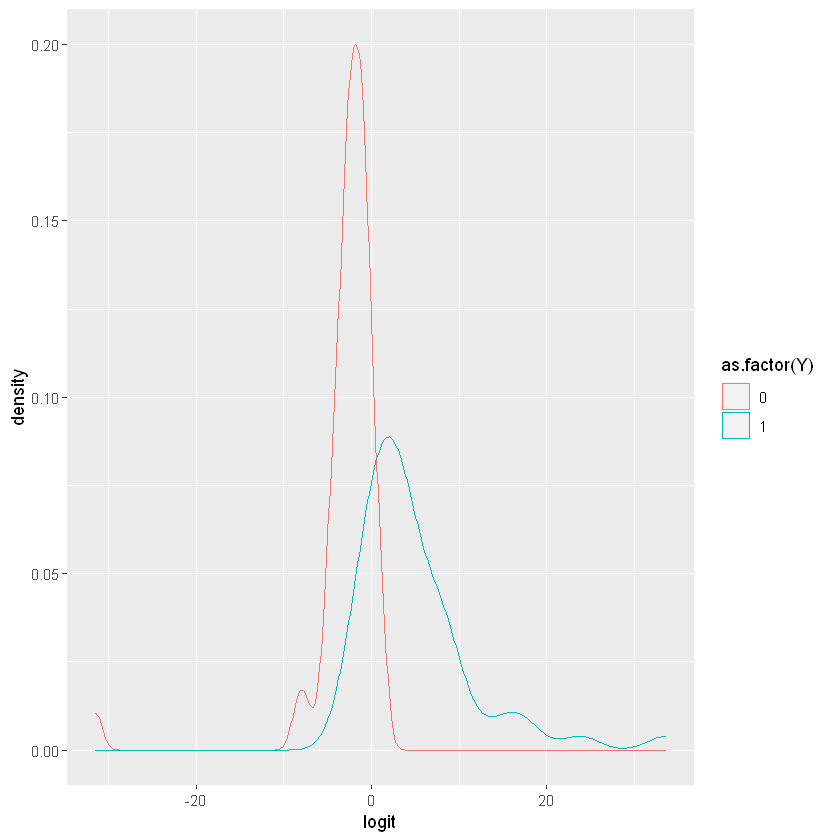

```r
ggplot(bankruptcy.logistic,aes(logit,group=as.factor(Y),colour=as.factor(Y)))+geom_density()
```

부도기업의 density는 0보다 작은 쪽에 치우쳐져 있고, 정상기업의 density는 0보다 큰 쪽에 치우쳐져 있다.

## (e) MLE의 분산공분산 행렬을 통해 신뢰구간 구하기

```r
logit.mle<-function(beta) {
  z<-beta[1]+beta[2]*bankruptcyH0$R5+beta[3]*bankruptcyH0$R6+beta[4]*bankruptcyH0$R16+beta[5]*bankruptcyH0$R18+beta[6]*bankruptcyH0$R22
  Gz<-1/(1+exp(-z))
  return(sum(log(Gz^bankruptcyH0$Y*(1-Gz)^(1-bankruptcyH0$Y))))
}
```

```r
result <- optimx(par=c(H0.coef),logit.mle)
result
```

|  | X.Intercept. | R5 | R6 | R16 | R18 | R22 | value | fevals | gevals | niter | convcode | kkt1 | kkt2 | xtime |
| --- | --- | --- | --- | --- | --- | --- | --- | --- | --- | --- | --- | --- | --- | --- |
| Nelder-Mead | 34.102066 | 30.02330 | -37.3817 | -44.57641 | 36.47666 | -3.905552 | -1672.14206 | 501 | NA | NA | 1 | NA | NA | 0.06 |
| BFGS | -2.183087 | 26.61332 | -29.5910 | -41.20542 | 31.25592 | 16.777606 | -30.05729 | 2 | 1 | NA | 0 | TRUE | FALSE | 0.00 |

```r
# 분산공분산 행렬 (In-1(beta))
mle <- c(result[2,1],result[2,2],result[2,3],result[2,4],result[2,5],result[2,6])

J <- -hessian(logit.mle,x=mle)
V <- solve(J)
V
```

| 0.3092558 | -1.72977 | 2.07423 | 1.98230 | -2.405695 | -0.9492806 |
| --- | --- | --- | --- | --- | --- |
| -1.7297698 | 69.79653 | -61.26598 | -75.79217 | 43.506245 | 17.7343155 |
| 2.0742303 | -61.26598 | 66.14695 | 77.27163 | -46.804952 | -29.2979208 |
| 1.9823003 | -75.79217 | 77.27163 | 217.41486 | -71.895257 | -147.4341593 |
| -2.4056953 | 43.50624 | -46.80495 | -71.89526 | 48.243341 | 27.9705547 |
| -0.9492806 | 17.73432 | -29.29792 | -147.43416 | 27.970555 | 146.9907676 |

```r
# 모수에 대한 90% 신뢰구간
se <- sqrt(diag(V))
CI_beta0<-c(mle[1]-1.645*se[1],mle[1]+1.645*se[1])
CI_beta1<-c(mle[2]-1.645*se[2],mle[2]+1.645*se[2])
CI_beta2<-c(mle[3]-1.645*se[3],mle[3]+1.645*se[3])
CI_beta3<-c(mle[4]-1.645*se[4],mle[4]+1.645*se[4])
CI_beta4<-c(mle[5]-1.645*se[5],mle[5]+1.645*se[5])
CI_beta5<-c(mle[6]-1.645*se[6],mle[6]+1.645*se[6])

cat("CI.beta0: [", CI_beta0[1], ",", CI_beta0[2], "] \n")
cat("CI.beta1: [", CI_beta1[1], ",", CI_beta1[2], "] \n")
cat("CI.beta2: [", CI_beta2[1], ",", CI_beta2[2], "] \n")
cat("CI.beta3: [", CI_beta3[1], ",", CI_beta3[2], "] \n")
cat("CI.beta4: [", CI_beta4[1], ",", CI_beta4[2], "] \n")
cat("CI.beta5: [", CI_beta5[1], ",", CI_beta5[2], "] ")
```

```
CI.beta0: [ -3.097884 , -1.26829 ]
CI.beta1: [ 12.87028 , 40.35636 ]
CI.beta2: [ -42.96991 , -16.21209 ]
CI.beta3: [ -65.46093 , -16.9499 ]
CI.beta4: [ 19.83017 , 42.68166 ]
CI.beta5: [ -3.166333 , 36.72154 ]
```

## (f) 최적모형의 오진율 vs 완전모형의 오진율

```r
# H0
prediction<-ifelse(prob>=0.5,1,0) # prob<-1/(1+exp(-betaX))
pred.table <- table(bankruptcyH0$Y,prediction)
pred.table
total.miss <- (pred.table[2]+pred.table[3]) / sum(pred.table)
cat("Total Misclassification Error : ", total.miss)
```

```
   prediction
     0  1
  0 45  5
  1  7 43
```

```
Total Misclassification Error :  0.12
```

```r
# H1
prob2<-predict(H1,type="response")
pred2.table<-ifelse(prob2>=0.5,1,0)
pred2.table <- table(bankruptcy$Y,pred2.table)
pred2.table
total2.miss <- (pred2.table[2]+pred2.table[3]) / sum(pred2.table)
cat("Total Misclassification Error : ", total2.miss)
```

```
   pred2.table
     0  1
  0 46  4
  1  8 42
```

```
Total Misclassification Error :  0.12
```

설명변수 5개를 이용한 최적모형(H0)의 오진율과 설명변수 24개를 이용한 완전모형(H1)의 오진율이 동일하다.  
-> 모형이 덜 복잡한 최적모형을 선택하는 것이 낫다고 판단할 수 있다.

# Part2. Sensitivity Analysis for MLE

## (a) Profile likelihood를 이용한 MLE 신뢰구간 구하기

```r
# profile likelihood
profile0<-function(a) {
  loglike<-function(b) {
    z<-a+b[1]*bankruptcy$R5+b[2]*bankruptcy$R6+b[3]*bankruptcy$R16+b[4]*bankruptcy$R18+b[5]*bankruptcy$R22
    Gz<-1/(1+exp(-z))
    return(sum(log(Gz^bankruptcy$Y*(1-Gz)^(1-bankruptcy$Y))))
  }
  return(optim(par=rep(mle[-1]),loglike,hessian=T,control=list(fnscale=-1))$value)
}

profile1<-function(a) {
  loglike<-function(b) {
    z<-b[1]+a*bankruptcy$R5+b[2]*bankruptcy$R6+b[3]*bankruptcy$R16+b[4]*bankruptcy$R18+b[5]*bankruptcy$R22
    Gz<-1/(1+exp(-z))
    return(sum(log(Gz^bankruptcy$Y*(1-Gz)^(1-bankruptcy$Y))))
  }
  return(optim(par=mle[-2],loglike,hessian=T,control=list(fnscale=-1))$value)
}

profile2<-function(a) {
  loglike<-function(b) {
    z<-b[1]+b[2]*bankruptcy$R5+a*bankruptcy$R6+b[3]*bankruptcy$R16+b[4]*bankruptcy$R18+b[5]*bankruptcy$R22
    Gz<-1/(1+exp(-z))
    return(sum(log(Gz^bankruptcy$Y*(1-Gz)^(1-bankruptcy$Y))))
  }
  return(optim(par=mle[-3],loglike,hessian=T,control=list(fnscale=-1))$value)
}

profile3<-function(a) {
  loglike<-function(b) {
    z<-b[1]+b[2]*bankruptcy$R5+b[3]*bankruptcy$R6+a*bankruptcy$R16+b[4]*bankruptcy$R18+b[5]*bankruptcy$R22
    Gz<-1/(1+exp(-z))
    return(sum(log(Gz^bankruptcy$Y*(1-Gz)^(1-bankruptcy$Y))))
  }
  return(optim(par=mle[-4],loglike,hessian=T,control=list(fnscale=-1))$value)
}

profile4<-function(a) {
  loglike<-function(b) {
    z<-b[1]+b[2]*bankruptcy$R5+b[3]*bankruptcy$R6+b[4]*bankruptcy$R16+a*bankruptcy$R18+b[5]*bankruptcy$R22
    Gz<-1/(1+exp(-z))
    return(sum(log(Gz^bankruptcy$Y*(1-Gz)^(1-bankruptcy$Y))))
  }
  return(optim(par=mle[-5],loglike,hessian=T,control=list(fnscale=-1))$value)
}

profile5<-function(a) {
  loglike<-function(b) {
    z<-b[1]+b[2]*bankruptcy$R5+b[3]*bankruptcy$R6+b[4]*bankruptcy$R16+b[5]*bankruptcy$R18+a*bankruptcy$R22
    Gz<-1/(1+exp(-z))
    return(sum(log(Gz^bankruptcy$Y*(1-Gz)^(1-bankruptcy$Y))))
  }
  return(optim(par=mle[-6],loglike,hessian=T,control=list(fnscale=-1))$value)
}
```

```r
# beta 추정
b0<-seq(-4,-1,length.out=100)
prof.loglike0<-c()
for (i in 1:length(b0)) {
  prof.loglike0[i]<-profile0(b0[i])
}

b1<-seq(10,45,length.out=100)
prof.loglike1<-c()
for (i in 1:length(b1)) {
  prof.loglike1[i]<-profile1(b1[i])
}

b2<-seq(-45,-15,length.out=100)
prof.loglike2<-c()
for (i in 1:length(b2)) {
  prof.loglike2[i]<-profile2(b2[i])
}

b3<-seq(-70,-15,length.out=100)
prof.loglike3<-c()
for (i in 1:length(b3)) {
  prof.loglike3[i]<-profile3(b3[i])
}

b4<-seq(20,45,length.out=100)
prof.loglike4<-c()
for (i in 1:length(b4)) {
  prof.loglike4[i]<-profile4(b4[i])
}

b5<-seq(-5,40,length.out=100)
prof.loglike5<-c()
for (i in 1:length(b5)) {
  prof.loglike5[i]<-profile5(b5[i])
}
```

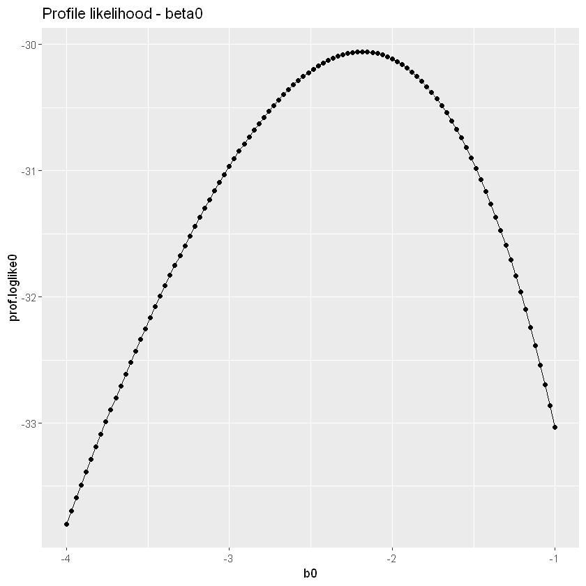

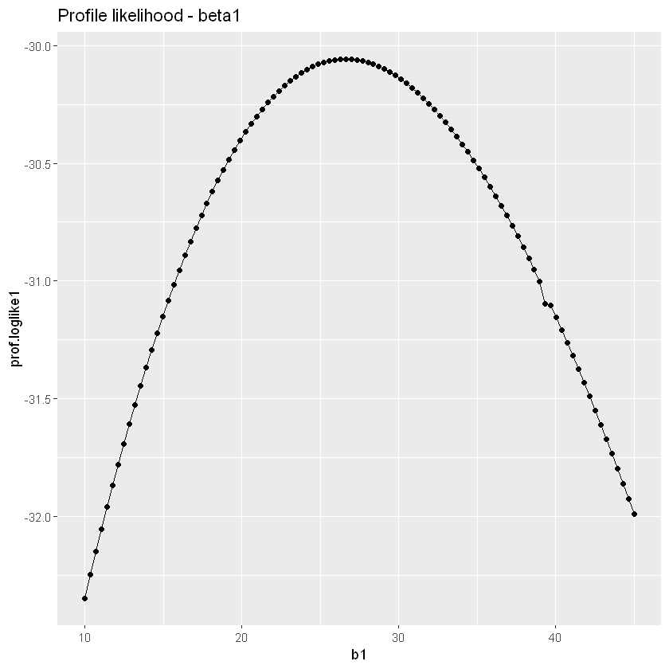

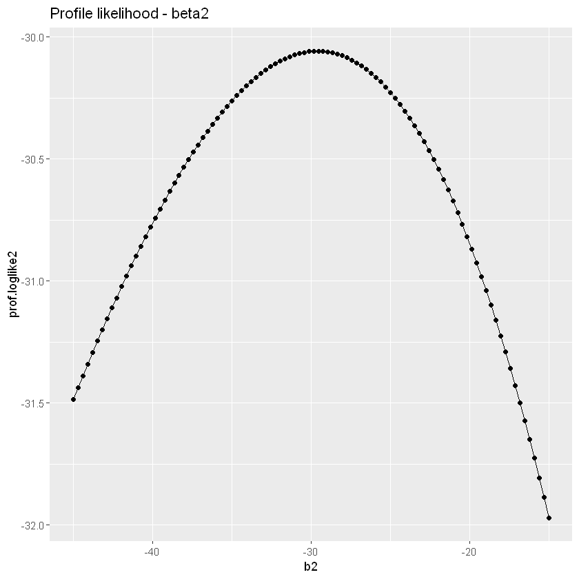

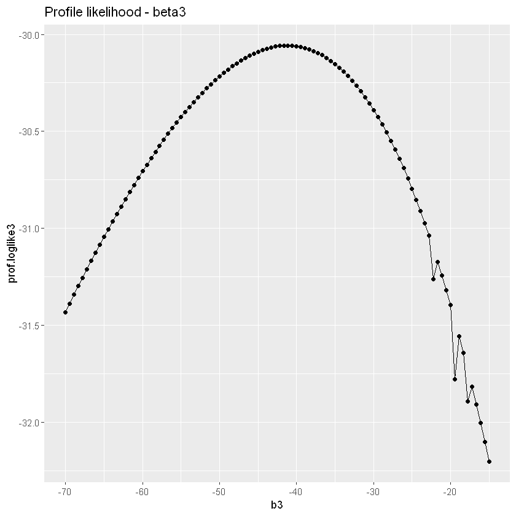

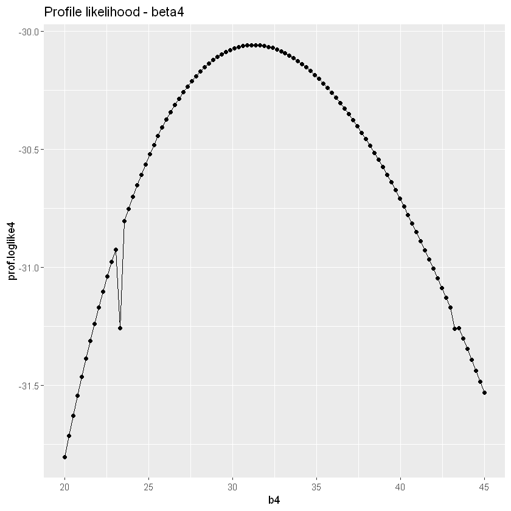

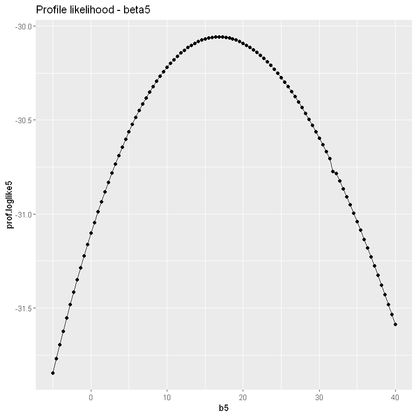

```r
# profile likelihood plot
ggplot(data.frame(b0,prof.loglike0),aes(b0,prof.loglike0))+geom_point()+geom_line()+ggtitle("Profile likelihood - beta0")
ggplot(data.frame(b1,prof.loglike1),aes(b1,prof.loglike1))+geom_point()+geom_line()+ggtitle("Profile likelihood - beta1")
ggplot(data.frame(b2,prof.loglike2),aes(b2,prof.loglike2))+geom_point()+geom_line()+ggtitle("Profile likelihood - beta2")
ggplot(data.frame(b3,prof.loglike3),aes(b3,prof.loglike3))+geom_point()+geom_line()+ggtitle("Profile likelihood - beta3")
ggplot(data.frame(b4,prof.loglike4),aes(b4,prof.loglike4))+geom_point()+geom_line()+ggtitle("Profile likelihood - beta4")
ggplot(data.frame(b5,prof.loglike5),aes(b5,prof.loglike5))+geom_point()+geom_line()+ggtitle("Profile likelihood - beta5")
```

```r
mydata<-data.frame(b0=b0,b1=b1,b2=b2,b3=b3,b4=b4,b5=b5,newy0=NA,newy1=NA,newy2=NA,newy3=NA,newy4=NA,newy5=NA)

for (i in 1:length(b0)) {
  mydata[i,7]<-sqrt(2*(profile0(mle[1])-profile0(mydata[i,1])))*sign(mydata[i,1]-mle[1])
  mydata[i,8]<-sqrt(2*(profile1(mle[2])-profile1(mydata[i,2])))*sign(mydata[i,2]-mle[2])
  mydata[i,9]<-sqrt(2*(profile2(mle[3])-profile2(mydata[i,3])))*sign(mydata[i,3]-mle[3])
  mydata[i,10]<-sqrt(2*(profile3(mle[4])-profile3(mydata[i,4])))*sign(mydata[i,4]-mle[4])
  mydata[i,11]<-sqrt(2*(profile4(mle[5])-profile4(mydata[i,5])))*sign(mydata[i,5]-mle[5])
  mydata[i,12]<-sqrt(2*(profile5(mle[6])-profile5(mydata[i,6])))*sign(mydata[i,6]-mle[6])
}
```

```r
CIb0<-b0[c(nrow(as.tibble(mydata) %>% filter(newy0<=-1.645))+1,100-nrow(as.tibble(mydata) %>% filter(newy0>=1.645)))]
CIb1<-b1[c(nrow(as.tibble(mydata) %>% filter(newy1<=-1.645))+1,100-nrow(as.tibble(mydata) %>% filter(newy1>=1.645)))]
CIb2<-b2[c(nrow(as.tibble(mydata) %>% filter(newy2<=-1.645))+1,100-nrow(as.tibble(mydata) %>% filter(newy2>=1.645)))]
CIb3<-b3[c(nrow(as.tibble(mydata) %>% filter(newy3<=-1.645))+1,100-nrow(as.tibble(mydata) %>% filter(newy3>=1.645)))]
CIb4<-b4[c(nrow(as.tibble(mydata) %>% filter(newy4<=-1.645))+1,100-nrow(as.tibble(mydata) %>% filter(newy4>=1.645)))]
CIb5<-b5[c(nrow(as.tibble(mydata) %>% filter(newy5<=-1.645))+1,100-nrow(as.tibble(mydata) %>% filter(newy5>=1.645)))]

cat("CI.beta0: [", CIb0[1], ",", CIb0[2], "] \n")
cat("CI.beta1: [", CIb1[1], ",", CIb1[2], "] \n")
cat("CI.beta2: [", CIb2[1], ",", CIb2[2], "] \n")
cat("CI.beta3: [", CIb3[1], ",", CIb3[2], "] \n")
cat("CI.beta4: [", CIb4[1], ",", CIb4[2], "] \n")
cat("CI.beta5: [", CIb5[1], ",", CIb5[2], "] ")
```

```
CI.beta0: [ -3.181818 , -1.363636 ]
CI.beta1: [ 13.88889 , 41.46465 ]
CI.beta2: [ -44.39394 , -17.42424 ]
CI.beta3: [ -69.44444 , -20 ]
CI.beta4: [ 21.26263 , 44.24242 ]
CI.beta5: [ -1.818182 , 38.18182 ]
```

## (b) Jackknife로 구한 MLE 분산공분산 행렬을 이용해 모수 신뢰구간 추정

```r
z<-c()
Gz<-c()
likelihood<-c()
l_ib<-c()
beta_i<-matrix(NA,ncol=nrow(bankruptcy),nrow=6)
```

```r
for (k in 1:nrow(bankruptcy)) {

  myfunc<-function(beta) {

    for (i in 1:nrow(bankruptcy)) {
      z[i]<-beta[1]+beta[2]*bankruptcy[i,"R5"]+beta[3]*bankruptcy[i,"R6"]+beta[4]*bankruptcy[i,"R16"]+beta[5]*bankruptcy[i,"R18"]+beta[6]*bankruptcy[i,"R22"]
      Gz[i]<-1/(1+exp(-z[i]))
      likelihood[i]<-sum(log(Gz[i]^bankruptcy[i,"Y"]*(1-Gz[i])^(1-bankruptcy[i,"Y"])))
    }

    l<-sum(likelihood)

    for (j in 1: nrow(bankruptcy)) {
      l_ib[j]<-l-likelihood[j]
    }
    return(l_ib)
  }

  myfunc2<-function(beta) {
    return(myfunc(beta)[k])
  }
  beta_i[,k]<-optim(par=mle,myfunc2,hessian=T,control=list(fnscale=-1))$par
}
```

```r
beta_i
```

| -2.192503 | -2.211554 | -2.160287 | -2.173984 | -2.151732 | -2.135151 | -2.205837 | -2.169396 | -2.145526 | -2.14379 | ... | -2.177024 | -2.182879 | -2.183087 | -2.412172 | -2.177054 | -2.521866 | -2.171251 | -2.181966 | -2.370492 | -2.330507 |
| --- | --- | --- | --- | --- | --- | --- | --- | --- | --- | --- | --- | --- | --- | --- | --- | --- | --- | --- | --- | --- |
| 26.488230 | 26.806644 | 26.411034 | 26.532888 | 26.571645 | 26.127935 | 32.881823 | 26.521485 | 26.297330 | 26.20296 | ... | 26.366819 | 26.612146 | 26.613325 | 32.979581 | 26.431741 | 29.365580 | 26.589584 | 26.589594 | 27.918746 | 27.461140 |
| -29.442432 | -30.216175 | -29.327550 | -29.470885 | -29.389482 | -28.796085 | -33.939524 | -29.488018 | -29.289587 | -29.28876 | ... | -29.352955 | -29.588176 | -29.591000 | -33.709232 | -29.387558 | -33.068774 | -29.608553 | -29.561532 | -31.105290 | -31.118501 |
| -39.310513 | -39.221571 | -41.051348 | -40.884568 | -40.578889 | -41.410218 | -45.794105 | -41.024252 | -41.311334 | -41.25145 | ... | -40.325471 | -41.200903 | -41.205417 | -46.017127 | -40.815446 | -44.707381 | -40.502397 | -41.156739 | -40.754032 | -41.332260 |
| 30.741938 | 32.344632 | 31.036653 | 31.140717 | 31.258051 | 31.171537 | 33.567534 | 31.123314 | 30.987825 | 30.94055 | ... | 30.762937 | 31.252415 | 31.255916 | 34.789702 | 31.031021 | 34.411349 | 30.818279 | 31.226196 | 32.247347 | 32.118534 |
| 15.740432 | 14.203784 | 16.762367 | 16.487932 | 15.920851 | 16.945988 | 17.399497 | 16.655678 | 17.443368 | 17.34032 | ... | 16.351773 | 16.774419 | 16.777606 | 15.023308 | 16.583304 | 18.667906 | 16.376474 | 16.750942 | 15.746547 | 16.549956 |

```r
beta_J<-apply(beta_i,1,mean)
Var_J<-matrix(0,ncol=6,nrow=6)
```

```r
for (i in 1:nrow(bankruptcy)) {
  Var_J<-Var_J+as.matrix(beta_i[,i]-beta_J)%*%t(as.matrix(beta_i[,i]-beta_J))
}
Var_J
```

| 0.433936 | -1.679923 | 1.465730 | 2.603819 | -2.645852 | -1.512050 |
| --- | --- | --- | --- | --- | --- |
| -1.679923 | 165.531708 | -132.334472 | -97.286394 | 69.779632 | -34.648138 |
| 1.465730 | -132.334472 | 137.637887 | 103.810888 | -69.814968 | -2.158734 |
| 2.603819 | -97.286394 | 103.810888 | 205.605331 | -73.731578 | -137.772779 |
| -2.645852 | 69.779632 | -69.814968 | -73.731578 | 53.250879 | 11.905359 |
| -1.512050 | -34.648138 | -2.158734 | -137.772779 | 11.905359 | 200.549017 |

```r
jackknife<-Var_J*(nrow(bankruptcy)/(nrow(bankruptcy)+1))
se_J<-sqrt(diag(jackknife))
```

```r
CI_b0_J<-c(beta_J[1]-1.645*se_J[1],beta_J[1]+1.645*se_J[1])
CI_b1_J<-c(beta_J[2]-1.645*se_J[2],beta_J[2]+1.645*se_J[2])
CI_b2_J<-c(beta_J[3]-1.645*se_J[3],beta_J[3]+1.645*se_J[3])
CI_b3_J<-c(beta_J[4]-1.645*se_J[4],beta_J[4]+1.645*se_J[4])
CI_b4_J<-c(beta_J[5]-1.645*se_J[5],beta_J[5]+1.645*se_J[5])
CI_b5_J<-c(beta_J[6]-1.645*se_J[6],beta_J[6]+1.645*se_J[6])
```

```r
cat("CI.beta0: [", CI_b0_J[1], ",", CI_b0_J[2], "] \n")
cat("CI.beta1: [", CI_b1_J[1], ",", CI_b1_J[2], "] \n")
cat("CI.beta2: [", CI_b2_J[1], ",", CI_b2_J[2], "] \n")
cat("CI.beta3: [", CI_b3_J[1], ",", CI_b3_J[2], "] \n")
cat("CI.beta4: [", CI_b4_J[1], ",", CI_b4_J[2], "] \n")
cat("CI.beta5: [", CI_b5_J[1], ",", CI_b5_J[2], "] ")
```

```
CI.beta0: [ -3.265887 , -1.109395 ]
CI.beta1: [ 5.541426 , 47.66021 ]
CI.beta2: [ -48.77459 , -10.36813 ]
CI.beta3: [ -64.74653 , -17.80552 ]
CI.beta4: [ 19.34961 , 43.23865 ]
CI.beta5: [ -6.338568 , 40.02165 ]
```

```r
smallz<-as.matrix(H0.coef.m)%*%as.matrix(mle)
pi_beta<-1/(1+exp(-smallz))
```

## d) CV로 실제 오진율 구하기

```r
betaX_i<-apply(as.matrix(H0.coef.m)*t(as.matrix(beta_i)),1,sum)
```

```r
prob_i<-1/(1+exp(-betaX_i))
pred_i<-ifelse(prob_i>=0.5,1,0)
pred_i.table <- table(bankruptcyH0$Y,pred_i)
pred_i.table
```

```
   pred_i
     0  1
  0 44  6
  1 11 39
```

```r
total_i.miss <- (pred_i.table[2]+pred_i.table[3]) / sum(pred_i.table)
cat("Total Misclassification Error : ", total_i.miss)
```

```
Total Misclassification Error :  0.17
```